# CMDA-3654

4. For each dataset, create a summary table for each variable in the data set. The descriptive statistics should include the mean, standard deviation, range, and number of missing values for that given variable. *Hint:* A very simple way to do this is to create an empty matrix, fill it with the needed values, and to name the rows and columns appropriately. Print your table nicely using `kable()` or `pandoc.table()`

```r
MeanT<-(apply(Toxic,2,mean,na.rm=T))
SDT<-(apply(Toxic,2,sd,na.rm=T))
RangeT<-(apply(Toxic,2,max,na.rm=T))-(apply(Toxic,2,min,na.rm=T))
MissingValuesT<-(apply(Toxic,2,function(x) sum(is.na(x))))

MeanNT<-(apply(Nontoxic,2,mean,na.rm=T))
SDNT<-(apply(Nontoxic,2,sd,na.rm=T))
RangeNT<-(apply(Nontoxic,2,max,na.rm=T))-(apply(Nontoxic,2,min,na.rm=T))
MissingValuesNT<-(apply(Nontoxic,2,function(x) sum(is.na(x))))

Tmatrix<-rbind(MeanT, SDT, RangeT, MissingValuesT)[,3:24]
Tmatrix
```

```
                    lars      lcad        lchr      lcop     llead     lmerc
MeanT           2.283596 -0.340354   3.5320143  4.128842  3.388027 -1.682065
SDT             1.059227  1.160208   0.6692169  1.031039  1.397571  1.257340
RangeT          8.533454  6.756932   3.1734135  6.145615  6.916054  7.649693
MissingValuesT 79.000000  0.000000 218.0000000 12.000000 79.000000  0.000000
                    lnick      lsilv      lzinc     lacen     lacpt     lanth
MeanT           3.2553517 -0.8968391  4.6263286  3.598841  3.357118  4.103581
SDT             0.6852677  1.2366288  0.8416856  1.660251  1.416576  1.767530
RangeT          3.5553481  6.7011410  5.5347061 11.097410 11.211820 12.154779
MissingValuesT 79.0000000  0.0000000 81.0000000  1.000000  0.000000  0.000000
                    lbaa      lban      lbap     lchry     lflan     lflen
MeanT           4.635919  3.446150  4.557458  4.993998  5.375908  3.697498
SDT             1.932893  1.639532  1.893056  1.984656  1.940302  1.694946
RangeT         12.611538 10.308953 11.512925 12.583367 12.468437 11.211820
MissingValuesT  0.000000  6.000000  0.000000  1.000000  6.000000  0.000000
                   lmeth    lnapt     lphen     lpyre
MeanT           3.760638 4.054879  4.971757  5.435742
SDT             1.629392 1.823850  1.874068  1.965622
RangeT          8.281471 9.803404 11.320554 12.128111
MissingValuesT 80.000000 0.000000  0.000000  6.000000
```

```r
NTmatrix<-rbind(MeanNT, SDNT, RangeNT, MissingValuesNT)[,3:24]
NTmatrix
```

```
                      lars      lcad       lchr      lcop     llead     lmerc
MeanNT           1.8400845 -1.472469  3.3401377  3.260988  2.599807 -2.583319
SDNT             0.8838987  1.371818  0.6332274  1.018562  1.053191  1.100811
RangeNT          4.8009148  5.886104  2.8081337  5.991465  8.318742  5.913503
MissingValuesNT 46.0000000  0.000000 78.0000000 17.000000 46.000000  0.000000
                     lnick     lsilv      lzinc    lacen    lacpt    lanth
MeanNT           3.1890359 -2.016522  4.0348399 2.550112 2.430355 2.966341
SDNT             0.6431917  1.251645  0.6352055 1.216577 1.206211 1.601188
RangeNT          3.5045150  6.066108  2.9519297 6.551080 7.431003 8.389360
MissingValuesNT 46.0000000  0.000000 47.0000000 4.000000 0.000000 1.000000
                    lbaa     lban     lbap    lchry    lflan    lflen     lmeth
MeanNT          3.315819 2.599771 3.241363 3.654486 4.048441 2.623760  2.496656
SDNT            1.725771 1.335641 1.699215 1.859554 1.816015 1.314582  1.258656
RangeNT         8.536996 8.242756 8.131531 9.126959 8.987197 6.437752  9.290383
MissingValuesNT 0.000000 1.000000 0.000000 4.000000 1.000000 0.000000 18.000000
                   lnapt    lphen    lpyre
MeanNT          2.839548 3.816098 3.937206
SDNT            1.530545 1.688103 1.863607
RangeNT         7.090077 7.901007 8.581732
MissingValuesNT 1.000000 0.000000 1.000000
```

```r
kable(Tmatrix)
```

|  | lars | lcad | lchr | lcop | llead | lmerc | lnick | lsilv | lzinc | lacen | lacpt | lanth | lbaa | lban | lbap | lchry | lflan | lflen | lmeth | lnapt | lphen | lpyre |
| --- | --- | --- | --- | --- | --- | --- | --- | --- | --- | --- | --- | --- | --- | --- | --- | --- | --- | --- | --- | --- | --- | --- |
| MeanT | 2.283596 | -0.340354 | 3.5320143 | 4.128842 | 3.388027 | -1.682065 | 3.2553517 | -0.8968391 | 4.6263286 | 3.598841 | 3.357118 | 4.103581 | 4.635919 | 3.446150 | 4.557458 | 4.993998 | 5.375908 | 3.697498 | 3.760638 | 4.054879 | 4.971757 | 5.435742 |
| SDT | 1.059227 | 1.160208 | 0.6692169 | 1.031039 | 1.397571 | 1.257340 | 0.6852677 | 1.2366288 | 0.8416856 | 1.660251 | 1.416576 | 1.767530 | 1.932893 | 1.639532 | 1.893056 | 1.984656 | 1.940302 | 1.694946 | 1.629392 | 1.823850 | 1.874068 | 1.965622 |
| RangeT | 8.533454 | 6.756932 | 3.1734135 | 6.145615 | 6.916054 | 7.649693 | 3.5553481 | 6.7011410 | 5.5347061 | 11.097410 | 11.211820 | 12.154779 | 12.611538 | 10.308953 | 11.512925 | 12.583367 | 12.468437 | 11.211820 | 8.281471 | 9.803404 | 11.320554 | 12.128111 |
| MissingValuesT | 79.000000 | 0.000000 | 218.0000000 | 12.000000 | 79.000000 | 0.000000 | 79.0000000 | 0.0000000 | 81.0000000 | 1.000000 | 0.000000 | 0.000000 | 0.000000 | 6.000000 | 0.000000 | 1.000000 | 6.000000 | 0.000000 | 80.000000 | 0.000000 | 0.000000 | 6.000000 |

```r
kable(NTmatrix)
```

|  | lars | lcad | lchr | lcop | llead | lmerc | lnick | lsilv | lzinc | lacen | lacpt | lanth | lbaa | lban | lbap | lchry | lflan | lflen | lmeth | lnapt | lphen | lpyre |
| --- | --- | --- | --- | --- | --- | --- | --- | --- | --- | --- | --- | --- | --- | --- | --- | --- | --- | --- | --- | --- | --- | --- |
| MeanNT | 1.8400845 | -1.472469 | 3.3401377 | 3.260988 | 2.599807 | -2.583319 | 3.1890359 | -2.016522 | 4.0348399 | 2.550112 | 2.430355 | 2.966341 | 3.315819 | 2.599771 | 3.241363 | 3.654486 | 4.048441 | 2.623760 | 2.496656 | 2.839548 | 3.816098 | 3.937206 |
| SDNT | 0.8838987 | 1.371818 | 0.6332274 | 1.018562 | 1.053191 | 1.100811 | 0.6431917 | 1.251645 | 0.6352055 | 1.216577 | 1.206211 | 1.601188 | 1.725771 | 1.335641 | 1.699215 | 1.859554 | 1.816015 | 1.314582 | 1.258656 | 1.530545 | 1.688103 | 1.863607 |
| RangeNT | 4.8009148 | 5.886104 | 2.8081337 | 5.991465 | 8.318742 | 5.913503 | 3.5045150 | 6.066108 | 2.9519297 | 6.551080 | 7.431003 | 8.389360 | 8.536996 | 8.242756 | 8.131531 | 9.126959 | 8.987197 | 6.437752 | 9.290383 | 7.090077 | 7.901007 | 8.581732 |
| MissingValuesNT | 46.0000000 | 0.000000 | 78.0000000 | 17.000000 | 46.000000 | 0.000000 | 46.0000000 | 0.000000 | 47.0000000 | 4.000000 | 0.000000 | 1.000000 | 0.000000 | 1.000000 | 0.000000 | 4.000000 | 1.000000 | 0.000000 | 18.000000 | 1.000000 | 0.000000 | 1.000000 |

#Found on google that apply function can find any metric applied to all columns(2) or rows(1) #Used na.rm to as a logical value that strips any NA value from the dataset #For the range I looked for the max value and subtracted the min of each column #For the missing values I looked up a function in google called sum(is.na) which calculate the amount of NA for every column using apply #Combine each calculated field by row starting from column 3 to 24 since the first 2 are not to be considered #Used kable to be able to create tables

# Problem 3: (25 pts) Common Plots in `Base R`.

Consider the dataset `cars.csv`. It contains information about 406 cars (in 407 rows - the first row is the names of the variables). Information on car name, mileage (MPG), number of cylinders, displacement, horsepower, weight, acceleration, model, and country of origin are available.

Answer the following questions based on this dataset.

1. Identify the types of each variable available in the dataset. Be as specific as you possibly can (Quantitative variables can be either Continuous vs discrete, Categorical can be either Nominal vs Ordinal etc).

```r
#For this mac use /Users/eduardosalvador/Desktop/CMDA / and if dataframe has header, equal it to true
cars <- read.csv(file = "/Users/eduardosalvador/Desktop/CMDA /Assignments/HW1/cars.csv", header =T)

typeof(cars$Car)
```

```
[1] "character"
```

```r
#Car is a Nominal type of vairable which falls in the Categorical group
typeof(cars$MPG)
```

```
[1] "double"
```

```r
#MPG is a Discrete type of variable which falls in the Quantitative group
typeof(cars$Cylinders)
```

```
[1] "integer"
```

```r
#Cylinders is a Discrete type of variable which falls in the Quantitative group
typeof(cars$Displacement)
```

```
[1] "double"
```

```r
#Displacement is a Contineous type of variable which falls in the Quantitative group
typeof(cars$Horsepower)
```

```
[1] "double"
```

```r
#Horsepower is a Discrete type of variable which falls in the Quantitative group
typeof(cars$Weight)
```

```
[1] "double"
```

```r
#Weight is a Continuous type of variable which falls in the Quantitative group
typeof(cars$Acceleration)
```

```
[1] "double"
```

```r
#Acceleration is a Discrete type of variable which falls in the Quantitative group
typeof(cars$Model)
```

```
[1] "integer"
```

```r
#Model is a Ordinal type of variable which falls in the Categorical group
typeof(cars$Origin)
```

```
[1] "character"
```

```r
#Origin is a Nominal type of variable which falls in the Categorical group
```

2. Make a histogram for the displacement variable first using `breaks = 5` and again with `breaks = 10`. Use relative frequencies (or densities). Label all the axes properly. Identify the skew of the histogram and the mode of the data.

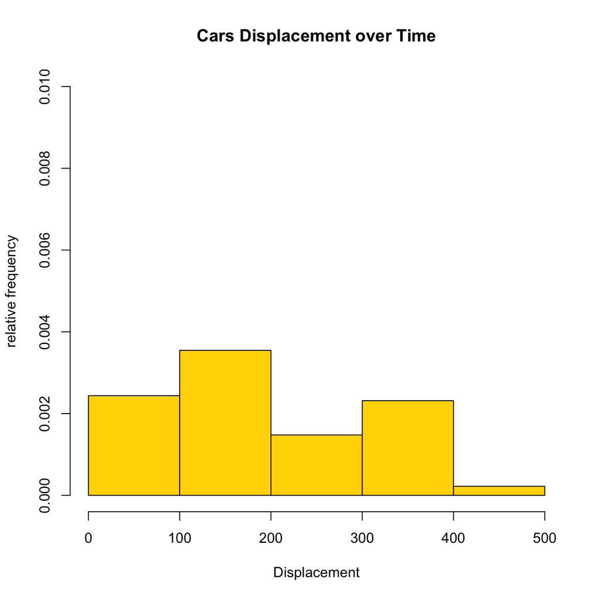

```r
hist(cars$Displacement, probability = T, xlim = c(0, 500) , ylim = c(0, 0.010),
     xlab = "Displacement", ylab = "relative frequency", main = "Cars Displacement over Time",
     breaks = 5, col="gold")
```

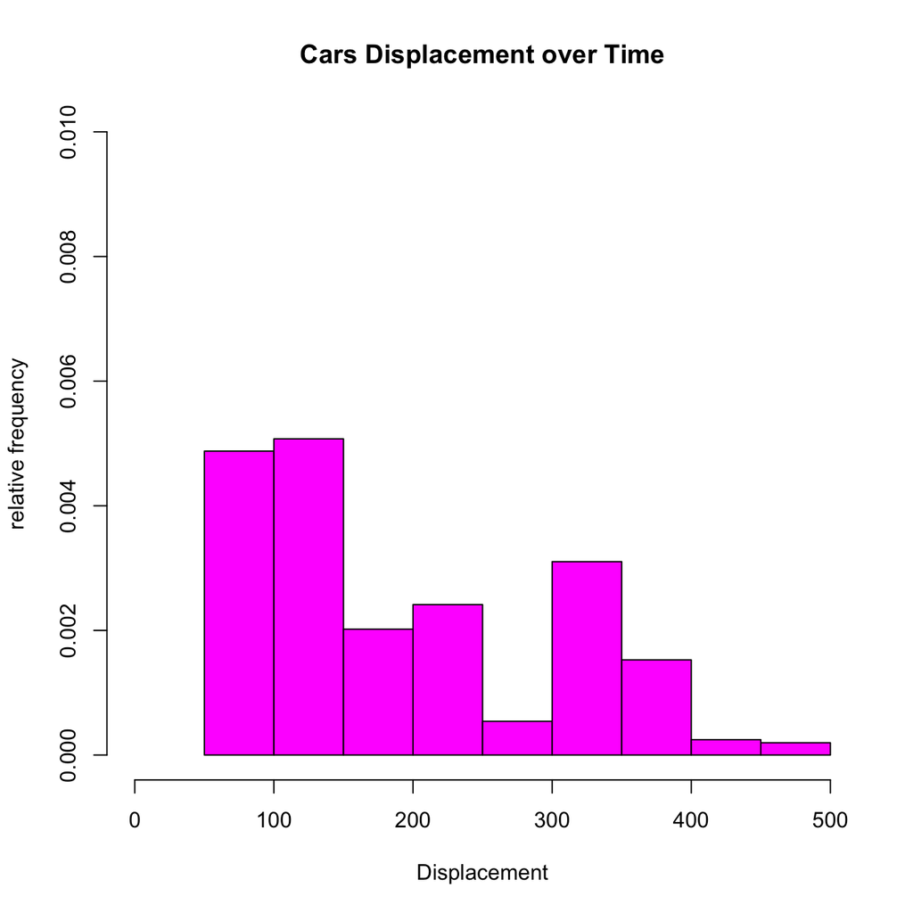

```r
hist(cars$Displacement, probability = T, xlim = c(0, 500) , ylim = c(0, 0.010),
     xlab = "Displacement", ylab = "relative frequency", main = "Cars Displacement over Time",
     breaks = 10, col="magenta")
```

```r
library(e1071)
skewness(cars$Displacement)
```

```
[1] 0.6890094
```

```r
#For mode created a table of cars displacement, coverted it into a data.frame, then to a character to be able to convert it gagin into numeric so that I could figure out which has the most frequencies. Then output this Var which has the most frequency
mode_1<-as.data.frame(table(cars$Displacement))
mode_1
```

| Var1 | Freq |
| --- | --- |
| 68 | 1 |
| 70 | 3 |
| 71 | 2 |
| 72 | 1 |
| 76 | 1 |
| 78 | 1 |
| 79 | 6 |
| 80 | 1 |
| 81 | 1 |
| 83 | 1 |

[output cut: 73 more lines]

```r
as.numeric(as.character(mode_1$Var1))
```

```
 [1]  68.0  70.0  71.0  72.0  76.0  78.0  79.0  80.0  81.0  83.0  85.0  86.0
[13]  88.0  89.0  90.0  91.0  96.0  97.0  97.5  98.0 100.0 101.0 104.0 105.0
[25] 107.0 108.0 110.0 111.0 112.0 113.0 114.0 115.0 116.0 119.0 120.0 121.0
[37] 122.0 130.0 131.0 133.0 134.0 135.0 140.0 141.0 144.0 145.0 146.0 151.0
[49] 155.0 156.0 163.0 168.0 171.0 173.0 181.0 183.0 198.0 199.0 200.0 225.0
[61] 231.0 232.0 250.0 258.0 260.0 262.0 267.0 302.0 304.0 305.0 307.0 318.0
[73] 340.0 350.0 351.0 360.0 383.0 390.0 400.0 429.0 440.0 454.0 455.0
```

```r
max_mode<-max(mode_1$Freq)
mode_1[mode_1$Freq==max_mode,1]
```

```
[1] 97
83 Levels: 68 70 71 72 76 78 79 80 81 83 85 86 88 89 90 91 96 97 97.5 ... 455
```

#Created histogram with details and for the skeweness downloaded package e1071 to get function skewness. #For mode created a table of cars displacement, coverted it into a data.frame, then to a character to be able to convert it gagin into numeric so that I could figure out which has the most frequencies. Then output this Var which has the most frequency

3. Make a kernel density estimation plot for the horsepower variable. Make a kernel density estimation plot for the horsepower variable, but this time exclude all vehicles that originate in the US.

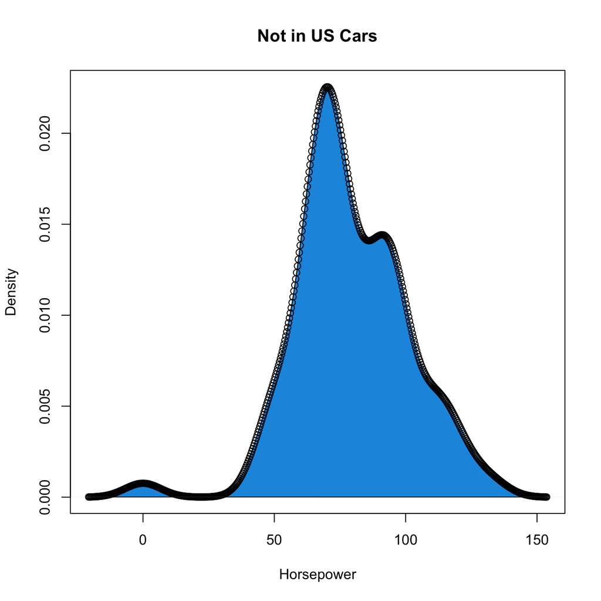

```r
Not_US<-subset(cars, Origin!="US")
plot(density(Not_US$Horsepower),
     main = "Not in US Cars",
     xlab = "Horsepower",
     ylab = "Density", polygon(density(Not_US$Horsepower), col = "#1b98e0", ))
```

#Created subset of cars data and use != as not equal to, to get rid of cars from the US. #Then created a density plot adding colors and a line on the edges with polygon and color function.

4. Generate a boxplot for the Horsepower variable. Discuss briefly what the boxplot indicates about the horsepower of the cars in the dataset. Generate a boxplot for the MPG variable. Do you notice any suspicious observations or outliers for MPG? Explain.

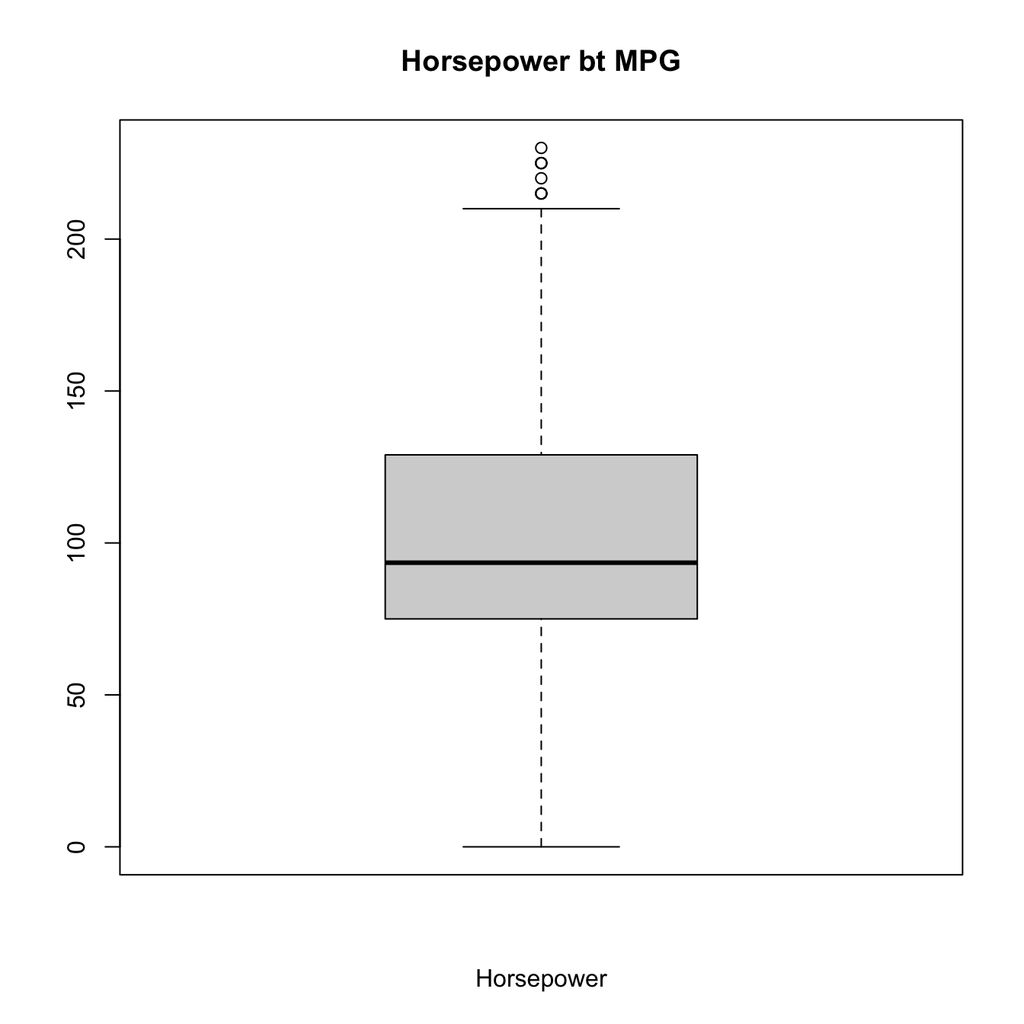

```r
boxplot( cars$Horsepower ,
         xlab = "Horsepower", ylab = "", main="Horsepower bt MPG")
```

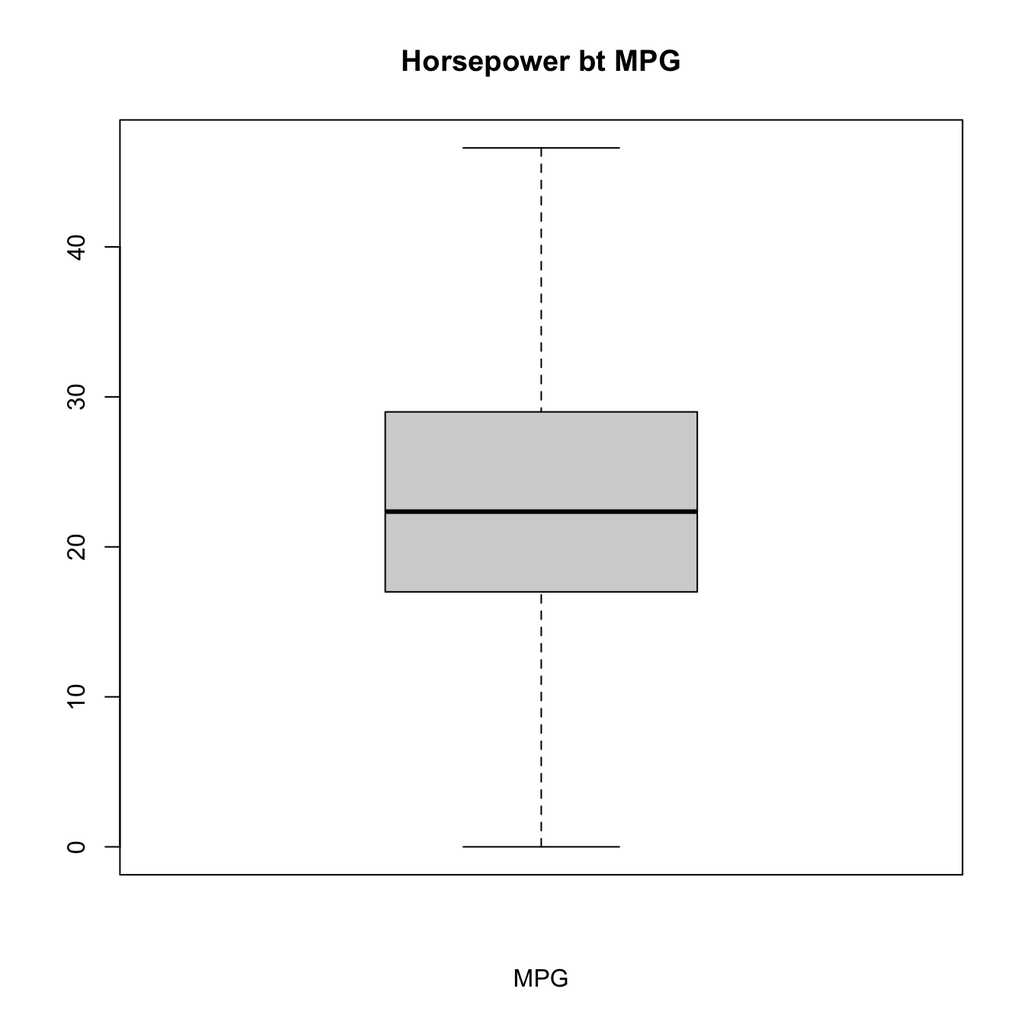

```r
boxplot( cars$MPG ,
         xlab = "MPG", ylab = "", main="Horsepower bt MPG")
```

#MPG outliers are every value of MPG which results in 0 since it is unreasonale to have a car with MPG at 0

5. For the cars that do not have suspicious observations for MPG, plot the MPG versus Horsepower. Repeat the above, but this time make three scatter plots. One for US cars, one for European Cars, and finally one for Japanese Cars.

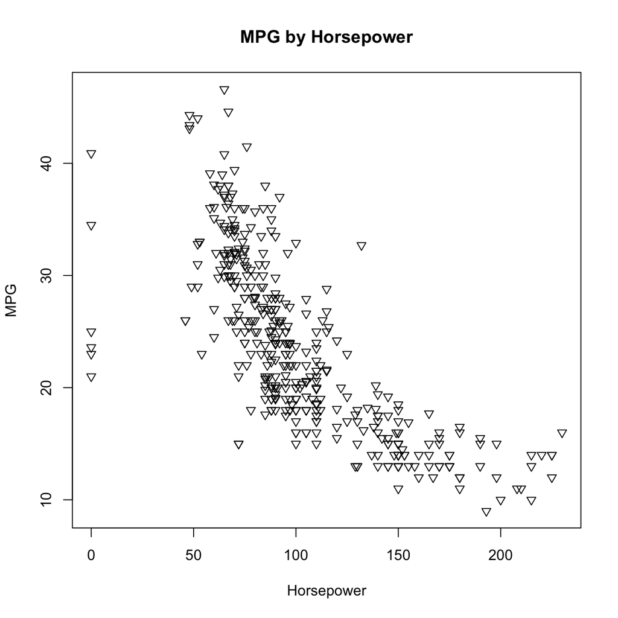

```r
Disregard_NMPG<-subset(cars, MPG!="0")
plot( Disregard_NMPG$MPG ~ Disregard_NMPG$Horsepower,
         xlab = "Horsepower", ylab = "MPG", main="MPG by Horsepower", pch=25)
```

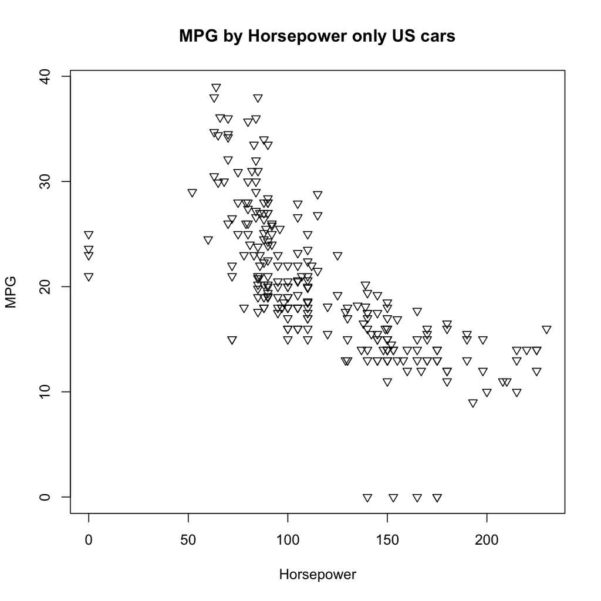

```r
US_cars<-subset(cars, Origin=="US", MPG!="0")
plot( US_cars$MPG ~ US_cars$Horsepower,
         xlab = "Horsepower", ylab = "MPG", main="MPG by Horsepower only US cars", pch=25)
```

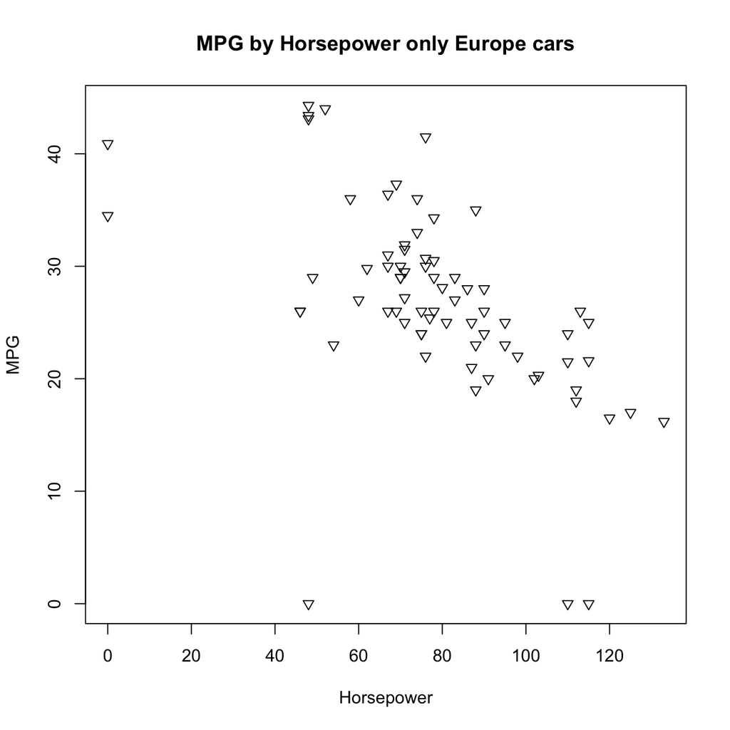

```r
Europe_cars<-subset(cars, Origin=="Europe", MPG!="0")
plot( Europe_cars$MPG ~ Europe_cars$Horsepower,
         xlab = "Horsepower", ylab = "MPG", main="MPG by Horsepower only Europe cars", pch=25)
```

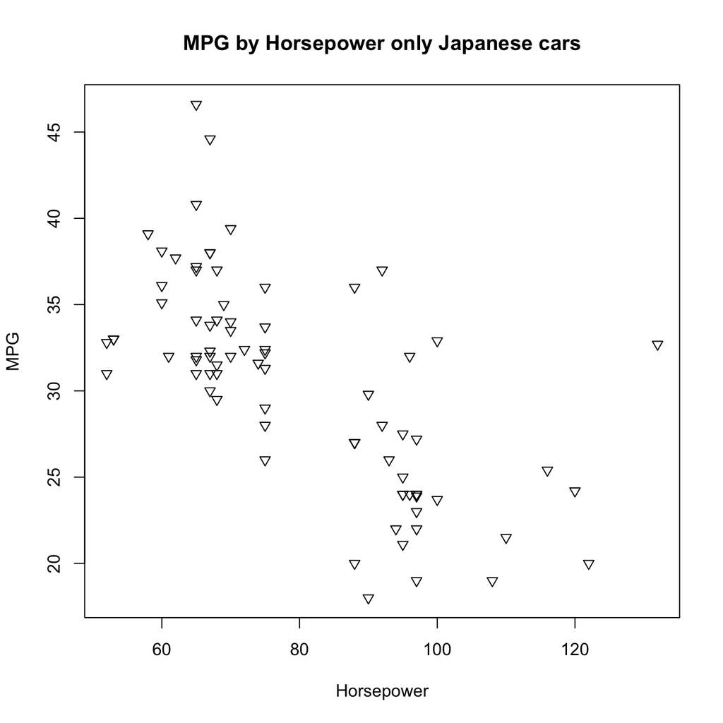

```r
Japanese_cars<-subset(cars, Origin=="Japan", MPG!="0")
plot( Japanese_cars$MPG ~ Japanese_cars$Horsepower,
         xlab = "Horsepower", ylab = "MPG", main="MPG by Horsepower only Japanese cars", pch=25)
```

# Problem 4: [25 pts]

Install the R package `babynames`. Load the `babynames` data and answer the following questions. Report R code and answers.

1. Describe the dataset in two sentences. How many rows and columns does the dataset have?

```r
library(babynames)
```

# The babynames dataset has 5 columns and 1,924,665 rows containing several entires of babies from 1880 to 2017, sex, Name of the baby, prop which is the variable prop represents the proportion of all applicants of that sex in that year that had that name and n which represents the number of applications in that year for that name and sex.

2. How many unique names are there in the dataset? Why is this number different from the number of rows in (a)?

```r
length(unique(babynames$name))
```

```
[1] 97310
```

##97310, it is different from the number of rows since some names repeat itself

3. What were the most popular male names for the years 1900, 1925, 1950, 1975, 2000? What were the most popular female names for the years 2010, 2011, 2012, 2013, 2014?

```r
Names_1900<-subset(subset(babynames, sex=="M"), year=="1900" )
Maxquant_1900=max(Names_1900$n)
Names_1900[Names_1900[,4]==Maxquant_1900, ]
```

| year | sex | name | n | prop |
| --- | --- | --- | --- | --- |
| 1900 | M | John | 9829 | 0.06062307 |

```r
Names_1925<-subset(subset(babynames, sex=="M"), year=="1925")
Maxquant_1925=max(Names_1925$n)
Names_1925[Names_1925[,4]==Maxquant_1925, ]
```

| year | sex | name | n | prop |
| --- | --- | --- | --- | --- |
| 1925 | M | Robert | 60896 | 0.05288659 |

```r
Names_1950<-subset(subset(babynames, sex=="M"), year=="1950")
Maxquant_1950=max(Names_1950$n)
Names_1950[Names_1950[,4]==Maxquant_1950, ]
```

| year | sex | name | n | prop |
| --- | --- | --- | --- | --- |
| 1950 | M | James | 86239 | 0.04740837 |

```r
Names_1975<-subset(subset(babynames, sex=="M"), year=="1975")
Maxquant_1975=max(Names_1975$n)
Names_1975[Names_1975[,4]==Maxquant_1975, ]
```

| year | sex | name | n | prop |
| --- | --- | --- | --- | --- |
| 1975 | M | Michael | 68454 | 0.0421767 |

```r
Names_2010<-subset(subset(babynames, sex=="F"), year=="2010")
Maxquant_2010=max(Names_2010$n)
Names_2010[Names_2010[,4]==Maxquant_2010, ]
```

| year | sex | name | n | prop |
| --- | --- | --- | --- | --- |
| 2010 | F | Isabella | 22905 | 0.01169646 |

```r
Names_2011<-subset(subset(babynames, sex=="F"), year=="2011")
Maxquant_2011=max(Names_2011$n)
Names_2011[Names_2011[,4]==Maxquant_2011, ]
```

| year | sex | name | n | prop |
| --- | --- | --- | --- | --- |
| 2011 | F | Sophia | 21837 | 0.011285 |

```r
Names_2012<-subset(subset(babynames, sex=="F"), year=="2012")
Maxquant_2012=max(Names_2012$n)
Names_2012[Names_2012[,4]==Maxquant_2012, ]
```

| year | sex | name | n | prop |
| --- | --- | --- | --- | --- |
| 2012 | F | Sophia | 22304 | 0.01151924 |

```r
Names_2013<-subset(subset(babynames, sex=="F"), year=="2013")
Maxquant_2013=max(Names_2013$n)
Names_2013[Names_2013[,4]==Maxquant_2013, ]
```

| year | sex | name | n | prop |
| --- | --- | --- | --- | --- |
| 2013 | F | Sophia | 21213 | 0.01102629 |

```r
Names_2014<-subset(subset(babynames, sex=="F"), year=="2014")
Maxquant_2014=max(Names_2014$n)
Names_2014[Names_2014[,4]==Maxquant_2014, ]
```

| year | sex | name | n | prop |
| --- | --- | --- | --- | --- |
| 2014 | F | Emma | 20924 | 0.01072117 |

4. What are the 10 most popular male baby names across years? What are the 10 most popular female baby names across years?

```r
PopularMaleNames<-subset(babynames, sex=="M")
DifferenciationM<-PopularMaleNames[PopularMaleNames[,3]==unique(PopularMaleNames$name),]

MaleNamesbyOrder<-DifferenciationM[order(DifferenciationM$n, decreasing=TRUE),]
MaleNamesbyOrder[1:10,3]
```

[output not shown]

```r
PopularFemaleNames<-subset(babynames, sex=="F")
DifferenciationF<-PopularFemaleNames[PopularFemaleNames[,3]==unique(PopularFemaleNames$name),]

FemaleNamesbyOrder<-DifferenciationF[order(DifferenciationF$n, decreasing=TRUE),]
FemaleNamesbyOrder[1:10,3]
```

[output not shown]

#Created a subset of babies only males and only females #Made the names unique so that it doesn’t repeat themselves in the list #Ordered the unique names from most to least and outputed the solution